# MTH6139 Time Series

Coursework 1 – CO2 Forecasting

Mark Aycicek

Spring term 2026

## Introduction

In my coursework, I am going to analyse the CO2 levels using Meta Prophet forecasting, where I will use different plots to show the trends and seasonal patterns.

CO2 refers to atmospheric carbon dioxide concentration, which is an important indicator of climate change and greenhouse gas levels.

The CO2 dataset contains measurements of atmospheric CO2 concentrations recorded at the Mauna Loa Observatory in Hawaii. The values are measured in parts per million (ppm) and span from 1959 to 1997 with monthly observations.

## CO2 Data

```r
data(co2)

start(co2)
```

```
## [1] 1959    1
```

```r
end(co2)
```

```
## [1] 1997   12
```

```r
frequency(co2)
```

```
## [1] 12
```

```r
summary(co2)
```

```
##    Min. 1st Qu.  Median    Mean 3rd Qu.    Max.
##   313.2   323.5   335.2   337.1   350.3   366.8
```

From the summary, we see that CO2 levels have increased substantially over time, with a range of over 50 ppm between the minimum and maximum values.

## CO2 Plot and Linear Regression

```r
time_numbered <- time(co2)
linear_model <- lm(co2 ~ time_numbered)
summary(linear_model)
```

```
##
## Call:
## lm(formula = co2 ~ time_numbered)
##
## Residuals:
##     Min      1Q  Median      3Q     Max
## -6.0399 -1.9476 -0.0017  1.9113  6.5149
##
## Coefficients:
##                 Estimate Std. Error t value Pr(>|t|)
## (Intercept)   -2.250e+03  2.127e+01  -105.8   <2e-16 ***
## time_numbered  1.308e+00  1.075e-02   121.6   <2e-16 ***
## ---
## Signif. codes:  0 '***' 0.001 '**' 0.01 '*' 0.05 '.' 0.1 ' ' 1
##
## Residual standard error: 2.618 on 466 degrees of freedom
## Multiple R-squared:  0.9695, Adjusted R-squared:  0.9694
## F-statistic: 1.479e+04 on 1 and 466 DF,  p-value: < 2.2e-16
```

In the linear regression summary, we see that the estimated coefficient is 1.308 meaning CO2 concentration is estimated to increase by 1.308 ppm every year in the model. You can also see the p-value is nearly 0, showing this coefficient has a strong statistical significance.

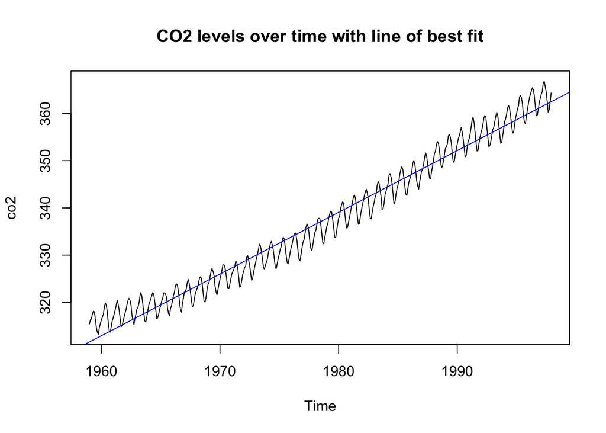

```r
plot(co2, main = "CO2 levels over time with line of best fit")
abline(linear_model, col = "blue")
```

The plot shows an overall increasing trend with seasonal fluctuations for different times during each year. The blue line is the line of best fit, which represents the upward trend, created by the linear model.

## Interactive Graph

```r
library(dygraphs)
dygraph(co2, main = "CO2 Levels") %>%
  dyRangeSelector()
```

[interactive chart not shown]

This plot is the same as the last one except it is an interactive graph that comes from the dygraphs package. You can zoom into specific intervals by dragging the range selector at the bottom, which allows you to see the patterns in different time periods. If you want the exact ppm for a particular month, you can just place your mouse over the graph and a green dot will show up on the line. Then, at the top, it shows the month, year and the CO2 concentration in ppm.

## Log transformation

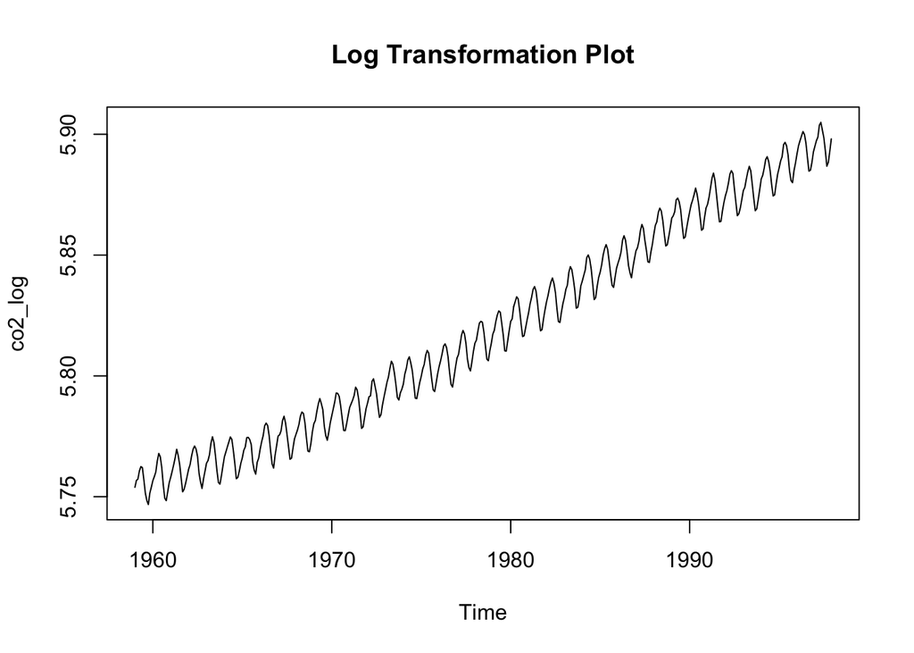

```r
co2_log <- log(co2)
plot(co2_log, main = "Log Transformation Plot")
```

As shown in the plot, the log transformed series looks essentially identical to the original, implying that the variance is fairly stable throughout and a transformation is not necessary.

## Preparing Prophet Data

```r
library(zoo)
time_date <- as.Date(as.yearmon(time(co2)))

co2_data <- data.frame(
  ds = time_date,
  y = as.numeric(co2)
)

head(co2_data)
```

```
##           ds      y
## 1 1959-01-01 315.42
## 2 1959-02-01 316.31
## 3 1959-03-01 316.50
## 4 1959-04-01 317.56
## 5 1959-05-01 318.13
## 6 1959-06-01 318.00
```

Here I converted the CO2 time series into two columns “ds” and “y” as it is required for the Prophet functions.